# Python in Aeronautics: Working with Aerodromes Data

## Welcome, Future Aviation GIS Specialists!

Today we're doing what real GIS Engineers do every day — taking raw aeronautical data and turning it into insights that keep aviation safe and efficient.

| **Our Dataset** | Aerodromes (airports/airfields) from the Kenya AIP |
| --- | --- |
| **Our Tools** | Python, Pandas, Matplotlib, JSON |
| **Our Mission** | Understand, analyze, and visualize airport data |

## Part 1: Python Basics Refresher

Before we dive into our aerodromes data, let's warm up with some Python fundamentals. Don't skip this even if you know Python — we're using aviation analogies!

### 1.1 VARIABLES - Like storing flight information

```python
# Think of variables as labels for important flight data
airport_name = "Jomo Kenyatta International"
icao_code = "HKJK"
elevation_feet = 5330
has_control_tower = True
runway_headings = [60, 240]  # List of runway directions

print(f"Welcome to {airport_name} ({icao_code})")
print(f"Elevation: {elevation_feet} feet above sea level")
print(f"Control Tower: {has_control_tower}")
print(f"Runway headings: {runway_headings}")
```

```
Welcome to Jomo Kenyatta International (HKJK)
Elevation: 5330 feet above sea level
Control Tower: True
Runway headings: [60, 240]
```

### 1.2 DATA TYPES - Different kinds of aviation information

```python
# Strings (text) - Airport names, codes
airport_name = "Wilson Airport"
airport_code = "HKNW"
print(f"Type of airport_code: {type(airport_code)}")

# Integers (whole numbers) - Elevation, runway counts
runway_count = 2
elevation = 5546
print(f"Type of runway_count: {type(runway_count)}")

# Floats (decimal numbers) - Coordinates, distances
latitude = -1.3217
longitude = 36.8148
print(f"Type of latitude: {type(latitude)}")

# Booleans (True/False) - Yes/No questions
has_ils = True  # Instrument Landing System
has_fuel = True
is_international = False
print(f"Type of has_ils: {type(has_ils)}")

# Lists (collections) - Multiple runways, multiple frequencies
frequencies = [118.1, 121.5, 126.2]  # Tower, Emergency, Approach
print(f"Type of frequencies: {type(frequencies)}")
```

```
Type of airport_code: <class 'str'>
Type of runway_count: <class 'int'>
Type of latitude: <class 'float'>
Type of has_ils: <class 'bool'>
Type of frequencies: <class 'list'>
```

### 1.3 LISTS - Managing collections of aerodromes

```python
# A list of ICAO codes for Kenyan airports
kenya_airports = ["HKJK", "HKNW", "HKKI", "HKMO", "HKEL"]
print(f"Kenya has {len(kenya_airports)} major airports in this list")
print(f"The first airport is: {kenya_airports[0]}")
print(f"The last airport is: {kenya_airports[-1]}")

# Adding a new airport
kenya_airports.append("HKLK")  # Lokichoggio
print(f"Updated list: {kenya_airports}")

# Slicing lists
first_three = kenya_airports[0:3]
print(f"First three airports: {first_three}")
```

```
Kenya has 5 major airports in this list
The first airport is: HKJK
The last airport is: HKEL
Updated list: ['HKJK', 'HKNW', 'HKKI', 'HKMO', 'HKEL', 'HKLK']
First three airports: ['HKJK', 'HKNW', 'HKKI']
```

### 1.4 DICTIONARIES - Perfect for airport details

```python
# A dictionary stores key-value pairs, like an airport's details
airport_hkjk = {
    "name": "Jomo Kenyatta International",
    "icao": "HKJK",
    "latitude": -1.3192,
    "longitude": 36.9278,
    "elevation_ft": 5330,
    "has_tower": True
}

print(f"Airport: {airport_hkjk['name']}")
print(f"Coordinates: {airport_hkjk['latitude']}, {airport_hkjk['longitude']}")

# Update information
airport_hkjk["weather_station"] = True
print(f"Weather station: {airport_hkjk['weather_station']}")
```

```
Airport: Jomo Kenyatta International
Coordinates: -1.3192, 36.9278
Weather station: True
```

### 1.5 FOR LOOPS - Processing multiple airports

```python
airports_list = [
    {"name": "Jomo Kenyatta Intl",  "icao": "HKJK", "elevation": 5330},
    {"name": "Wilson Airport",       "icao": "HKNW", "elevation": 5546},
    {"name": "Kisumu Intl",          "icao": "HKKI", "elevation": 3795},
    {"name": "Moi Intl",             "icao": "HKMO", "elevation": 200},
    {"name": "Eldoret Intl",         "icao": "HKEL", "elevation": 6945}
]

print("All Airports:")
for airport in airports_list:
    print(f"  - {airport['name']} ({airport['icao']}): {airport['elevation']} ft")

print("\nHigh Altitude Airports (>5000 ft):")
for airport in airports_list:
    if airport['elevation'] > 5000:
        print(f"  • {airport['name']} at {airport['elevation']} ft")
```

```
All Airports:
  - Jomo Kenyatta Intl (HKJK): 5330 ft
  - Wilson Airport (HKNW): 5546 ft
  - Kisumu Intl (HKKI): 3795 ft
  - Moi Intl (HKMO): 200 ft
  - Eldoret Intl (HKEL): 6945 ft

High Altitude Airports (>5000 ft):
  • Jomo Kenyatta Intl at 5330 ft
  • Wilson Airport at 5546 ft
  • Eldoret Intl at 6945 ft
```

### 1.6 WHILE LOOPS - Monitoring conditions

```python
# Simulating a descent check until landing
altitude = 10000  # feet
target_altitude = 0

print("Starting descent...")
while altitude > target_altitude:
    print(f"  Altitude: {altitude} ft")
    altitude -= 1000  # descending 1000 ft at a time
    if altitude == 2000:
        print("  ⚠️  Entering traffic pattern")
print("🛬 Landed!")
```

```
Starting descent...
  Altitude: 10000 ft
  Altitude: 9000 ft
  Altitude: 8000 ft
  Altitude: 7000 ft
  Altitude: 6000 ft
  Altitude: 5000 ft
  Altitude: 4000 ft
  Altitude: 3000 ft
  ⚠️  Entering traffic pattern
  Altitude: 2000 ft
  Altitude: 1000 ft
🛬 Landed!
```

### 1.7 FUNCTIONS - Reusable aviation tools

```python
def meters_to_feet(meters):
    """Convert meters to feet (aviation uses feet!)"""
    return meters * 3.28084

def feet_to_meters(feet):
    """Convert feet to meters"""
    return feet / 3.28084

runway_length_m = 3000
print(f"Runway {runway_length_m}m = {meters_to_feet(runway_length_m):.0f} ft")

elevation_ft = 5330
print(f"Elevation {elevation_ft} ft = {feet_to_meters(elevation_ft):.0f} m")
```

```
Runway 3000m = 9843 ft
Elevation 5330 ft = 1625 m
```

### 1.8 A GIS-SPECIFIC FUNCTION - Bearing between two aerodromes

```python
import math
import folium

def calculate_bearing(lat1, lon1, lat2, lon2):
    """Calculate bearing (direction) between two points."""
    lat1, lon1, lat2, lon2 = map(math.radians, [lat1, lon1, lat2, lon2])
    dlon = lon2 - lon1
    x = math.sin(dlon) * math.cos(lat2)
    y = math.cos(lat1) * math.sin(lat2) - math.sin(lat1) * math.cos(lat2) * math.cos(dlon)
    bearing = (math.degrees(math.atan2(x, y)) + 360) % 360
    return bearing

# Bearing from JKIA to Wilson Airport
bearing = calculate_bearing(-1.3192, 36.9278, -1.3213, 36.8150)
print(f"Bearing from JKIA to Wilson: {bearing:.1f}°")
```

```
Bearing from JKIA to Wilson: 268.9°
```

## Part 2: Loading Real Aerodromes Data

Now we're ready to work with actual aerodromes data from the **Kenya AIP GeoJSON** file. We'll parse it into a Pandas DataFrame and explore its structure.

### 2.1 IMPORTING OUR TOOLS

```python
import json
import pandas as pd
import matplotlib.pyplot as plt
import numpy as np
import math

plt.style.use('seaborn-v0_8-darkgrid')
%matplotlib inline

print("✅ Libraries imported successfully!")
```

```
✅ Libraries imported successfully!
```

### 2.2 LOADING THE AERODROMES GEOJSON

```python
# The GeoJSON file contains aerodrome points from the Kenya AIP.
# Each feature has 'properties' (attributes) and 'geometry' (coordinates).

with open('aerodromes-ke.geojson', 'r', encoding='utf-8') as f:
    geojson_data = json.load(f)

# Parse features into a flat list of records
records = []
for feature in geojson_data['features']:
    props = feature['properties'].copy()
    coords = feature['geometry']['coordinates']  # [longitude, latitude]
    props['longitude'] = coords[0]
    props['latitude']  = coords[1]
    records.append(props)

aerodromes_raw = pd.DataFrame(records)

print(f"✅ Loaded {len(aerodromes_raw)} aerodromes")
aerodromes_raw.head()
```

```
✅ Loaded 19 aerodromes
```

|  | fid | ICAO_Code | Type | Latitude | Longitude | Elevation_m_ft | Geoid_Undulation_m | Remarks_Spatial | Admin_Company | Admin_Address | Admin_Telephone | Admin_AFS | Admin_Email | Traffic_Permitted | Magnetic_Variation | Annual_Change | Remarks_NonSpatial | Admin_Website | longitude | latitude |
| --- | --- | --- | --- | --- | --- | --- | --- | --- | --- | --- | --- | --- | --- | --- | --- | --- | --- | --- | --- | --- |
| 0 | 1 | HKEL | ARP | 002414.44N | 0351412.17E | 6945 FT (2117 M) | -44 FT (-13.42 M) | 076°/1750 M from THR 08. 180°, 15 KM south of ... | Kenya Airports Authority | P.O. - Box 2323 Eldoret | Tel: 254 53 63377 Tel: 254 53 61299 Fax: 254 5... | HKELYDYX | kaa.ela@africaonline.co.ke | IFR/VFR | 1° E (2020) | 0°1' E | NIL | None | 35.236714 | 0.404011 |
| 1 | 2 | HKEM | ARP | 003420.42S | 0372941.42E | 4173 FT (1272 M) | NIL | 7 KM south East of Embu town. Reference temper... | Kenya Airports Authority | P.O. - Box 19001 00501 Nairobi | Tel: 254-20-6822400 Fax: 254-20-6822078 | NIL | NIL | IFR/VFR | 1° E | NIL | NIL | None | 37.494839 | -0.572339 |
| 2 | 3 | HKFP | ARP | 011130.00S | 0365842.65E | 4953 FT (1510 M) | -53 FT (-16.15 M) | NE of Nairobi CBD. Approx. 19 km. Reference te... | NORTHLANDS LTD | P.O. BOX 236 00232 RUIRU | NIL | NIL | airstrip@northlands.co.ke | IFR/VFR | 1°6' E (2025) | NIL | NIL | www.northlands.co.ke | 36.978514 | -1.191667 |
| 3 | 4 | HKIS | ARP | 002016.21N | 0373529.56E | 3768.17 FT (1149 M) | -57 FT (-17.38 M) | Approximately 1KM SE of Isiolo Town. Reference... | Kenya Airports Authority | P. O. - Box 187 60300 Isiolo | NIL | NIL | NIL | IFR/VFR | 0° W (2020) | NIL | 1)ACFT taking off from RWY 33 are requested to... | None | 37.591544 | 0.337836 |
| 4 | 5 | HKJK | ARP | 011909.27S | 0365539.99E | 5330 FT (1625 M) | -52 FT (-15.95 M) | 054°/1525 M from THR 06. 135°,18 KM from Nairo... | Kenya Airports Authority | P .O. - Box 19087 Nairobi | Tel: 254 20 6822111 Fax: 254 20 6822078 | HKJKYDYX | NIL | IFR/VFR | 1° E (2020) | 0°0' W | NIL | None | 36.927775 | -1.319242 |

### 2.3 CLEANING & PREPARING THE DATA

```python
# The Elevation_m_ft column stores values like "5330 FT (1625 M)" or "1690 / 5546".
# We'll extract just the feet value.

import re

def parse_elevation_ft(raw):
    """Extract the first numeric value from an elevation string (feet)."""
    if pd.isna(raw):
        return np.nan
    # Match the first integer or decimal number in the string
    match = re.match(r'([\d.]+)', str(raw).strip())
    if match:
        return float(match.group(1))
    return np.nan

# Build a clean working DataFrame
aerodromes = pd.DataFrame({
    'name':              aerodromes_raw['ICAO_Code'],          # use ICAO as primary label
    'icao':              aerodromes_raw['ICAO_Code'],
    'type':              aerodromes_raw['Type'],
    'traffic':           aerodromes_raw['Traffic_Permitted'],
    'operator':          aerodromes_raw['Admin_Company'],
    'latitude':          aerodromes_raw['latitude'],
    'longitude':         aerodromes_raw['longitude'],
    'elevation_raw':     aerodromes_raw['Elevation_m_ft'],
    'elevation_ft':      aerodromes_raw['Elevation_m_ft'].apply(parse_elevation_ft),
    'remarks':           aerodromes_raw['Remarks_NonSpatial'],
})

print("\nCleaned DataFrame:")
aerodromes.head()
```

```
Cleaned DataFrame:
```

|  | name | icao | type | traffic | operator | latitude | longitude | elevation_raw | elevation_ft | remarks |
| --- | --- | --- | --- | --- | --- | --- | --- | --- | --- | --- |
| 0 | HKEL | HKEL | ARP | IFR/VFR | Kenya Airports Authority | 0.404011 | 35.236714 | 6945 FT (2117 M) | 6945.00 | NIL |
| 1 | HKEM | HKEM | ARP | IFR/VFR | Kenya Airports Authority | -0.572339 | 37.494839 | 4173 FT (1272 M) | 4173.00 | NIL |
| 2 | HKFP | HKFP | ARP | IFR/VFR | NORTHLANDS LTD | -1.191667 | 36.978514 | 4953 FT (1510 M) | 4953.00 | NIL |
| 3 | HKIS | HKIS | ARP | IFR/VFR | Kenya Airports Authority | 0.337836 | 37.591544 | 3768.17 FT (1149 M) | 3768.17 | 1)ACFT taking off from RWY 33 are requested to... |
| 4 | HKJK | HKJK | ARP | IFR/VFR | Kenya Airports Authority | -1.319242 | 36.927775 | 5330 FT (1625 M) | 5330.00 | NIL |

### 2.4 UNDERSTANDING OUR DATA

```python
print("Column names:")
print(aerodromes.columns.tolist())

print("\nData types:")
print(aerodromes.dtypes)

print("\nNumerical summary:")
aerodromes[['latitude', 'longitude', 'elevation_ft']].describe()
```

```
Column names:
['name', 'icao', 'type', 'traffic', 'operator', 'latitude', 'longitude', 'elevation_raw', 'elevation_ft', 'remarks']

Data types:
name              object
icao              object
type              object
traffic           object
operator          object
latitude         float64
longitude        float64
elevation_raw     object
elevation_ft     float64
remarks           object
dtype: object

Numerical summary:
```

|  | latitude | longitude | elevation_ft |
| --- | --- | --- | --- |
| count | 19.000000 | 19.000000 | 19.000000 |
| mean | -0.748864 | 37.033769 | 3071.701421 |
| std | 1.993530 | 2.143913 | 2380.079991 |
| min | -4.293592 | 34.348192 | 13.000000 |
| 25% | -1.364968 | 35.034332 | 877.000000 |
| 50% | -1.116067 | 36.927775 | 3768.170000 |
| 75% | 0.304622 | 38.581396 | 4991.690000 |
| max | 4.204094 | 40.913108 | 6945.000000 |

### 2.5 EXPLORING CATEGORICAL DATA

```python
print("Aerodrome types (from GeoJSON 'Type' field):")
print(aerodromes['type'].value_counts())

print("\nTraffic permitted:")
print(aerodromes['traffic'].value_counts())

print("\nOperating organizations:")
print(aerodromes['operator'].value_counts())
```

```
Aerodrome types (from GeoJSON 'Type' field):
type
ARP    19
Name: count, dtype: int64

Traffic permitted:
traffic
IFR/VFR    16
VFR         3
Name: count, dtype: int64

Operating organizations:
operator
Kenya Airports Authority                17
NORTHLANDS LTD                           1
Kenya Air Force, Ministry Of Defence     1
Name: count, dtype: int64
```

### 2.6 CHECKING FOR MISSING DATA

```python
missing_data = aerodromes.isnull().sum()
print("Missing values per column:")
print(missing_data)

total_cells = aerodromes.shape[0] * aerodromes.shape[1]
missing_cells = missing_data.sum()
completeness = ((total_cells - missing_cells) / total_cells) * 100
print(f"\nDataset completeness: {completeness:.1f}%")
```

```
Missing values per column:
name             0
icao             0
type             0
traffic          0
operator         0
latitude         0
longitude        0
elevation_raw    0
elevation_ft     0
remarks          0
dtype: int64

Dataset completeness: 100.0%
```

### 2.7 BASIC FILTERING AND QUERIES

```python
# Aerodromes that support IFR (Instrument Flight Rules)
ifr_airports = aerodromes[aerodromes['traffic'].str.contains('IFR', na=False)]
print(f"IFR-capable aerodromes: {len(ifr_airports)}")
print(ifr_airports[['icao', 'traffic', 'elevation_ft']])

# High elevation aerodromes (> 5000 ft)
high_altitude = aerodromes[aerodromes['elevation_ft'] > 5000]
print(f"\nHigh altitude (>5000 ft): {len(high_altitude)}")
high_altitude[['icao', 'elevation_ft']].sort_values('elevation_ft', ascending=False)
```

```
IFR-capable aerodromes: 16
    icao  traffic  elevation_ft
0   HKEL  IFR/VFR       6945.00
1   HKEM  IFR/VFR       4173.00
2   HKFP  IFR/VFR       4953.00
3   HKIS  IFR/VFR       3768.17
4   HKJK  IFR/VFR       5330.00
6   HKKI  IFR/VFR       3795.00
8   HKLK  IFR/VFR       2115.00
9   HKLU  IFR/VFR         18.00
11  HKML  IFR/VFR         88.00
12  HKMO  IFR/VFR        199.60
13  HKNL  IFR/VFR       6253.00
14  HKNW  IFR/VFR       1690.00
15  HKOK  IFR/VFR       1523.00
16  HKRE  IFR/VFR       1626.00
17  HKUK  IFR/VFR         13.00
18  HKWJ  IFR/VFR        231.00

High altitude (>5000 ft): 5
```

|  | icao | elevation_ft |
| --- | --- | --- |
| 0 | HKEL | 6945.000 |
| 13 | HKNL | 6253.000 |
| 7 | HKKT | 5995.177 |
| 4 | HKJK | 5330.000 |
| 5 | HKKG | 5030.380 |

## Part 3: Visualizing Aerodromes

Now let's start creating maps and visualizations. This is where GIS thinking meets Python!

### 3.1 SIMPLE SCATTER PLOT - All Aerodromes

```python
# Interactive Map using Folium
import folium
m = folium.Map(location=[-1.286389, 36.817222], zoom_start=6)  # Centered on Kenya

for _, row in aerodromes.iterrows():
    folium.Marker(
        location=[row['latitude'], row['longitude']],
        popup=f"ICAO: {row['icao']}<br>Name: {row['name']}<br>Elevation: {row['elevation_ft']} ft",
        tooltip=row['icao']
    ).add_to(m)

m
```

Make this Notebook Trusted to load map: File -> Trust Notebook

[interactive chart not shown]

### 3.2 COLOR-CODING BY TRAFFIC TYPE (IFR vs VFR)

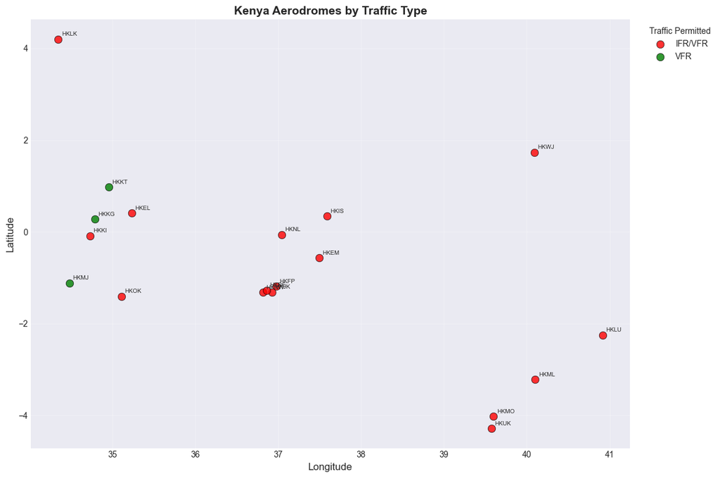

```python
plt.figure(figsize=(12, 8))

traffic_colors = {
    'IFR/VFR': 'red',
    'VFR':     'green',
}

for traffic_type, color in traffic_colors.items():
    subset = aerodromes[aerodromes['traffic'] == traffic_type]
    if len(subset) > 0:
        plt.scatter(subset['longitude'], subset['latitude'],
                    label=traffic_type, c=color, alpha=0.8, s=80,
                    edgecolors='black', linewidth=0.6)

# Label points
for _, row in aerodromes.iterrows():
    plt.annotate(row['icao'], (row['longitude'], row['latitude']),
                 xytext=(4, 4), textcoords='offset points', fontsize=7)

plt.xlabel('Longitude', fontsize=12)
plt.ylabel('Latitude', fontsize=12)
plt.title('Kenya Aerodromes by Traffic Type', fontsize=14, fontweight='bold')
plt.legend(title='Traffic Permitted', bbox_to_anchor=(1.02, 1), loc='upper left')
plt.grid(True, alpha=0.3)
plt.tight_layout()
plt.show()
```

### 3.3 SIZE BY ELEVATION

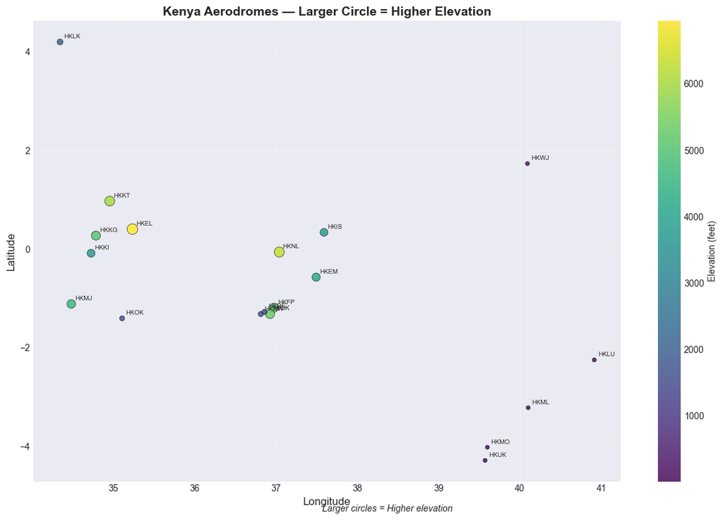

```python
plt.figure(figsize=(12, 8))

sizes = aerodromes['elevation_ft'].fillna(0) / 50
sizes = sizes.clip(20, 200)

scatter = plt.scatter(
    aerodromes['longitude'], aerodromes['latitude'],
    c=aerodromes['elevation_ft'], s=sizes,
    cmap='viridis', alpha=0.8, edgecolors='black', linewidth=0.5
)

plt.colorbar(scatter, label='Elevation (feet)')

for _, row in aerodromes.iterrows():
    plt.annotate(row['icao'], (row['longitude'], row['latitude']),
                 xytext=(4, 4), textcoords='offset points', fontsize=7)

plt.xlabel('Longitude', fontsize=12)
plt.ylabel('Latitude', fontsize=12)
plt.title('Kenya Aerodromes — Larger Circle = Higher Elevation', fontsize=14, fontweight='bold')
plt.figtext(0.5, 0.01, 'Larger circles = Higher elevation', ha='center', fontsize=10, style='italic')
plt.grid(True, alpha=0.3)
plt.tight_layout()
plt.show()
```

### 3.4 ELEVATION DISTRIBUTION

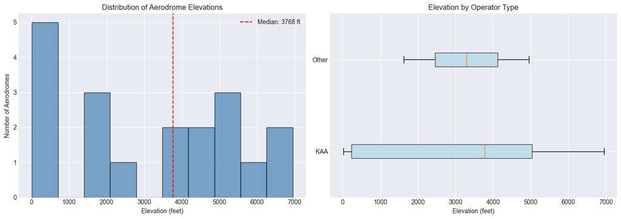

```python
fig, axes = plt.subplots(1, 2, figsize=(14, 5))

# Histogram
elev_clean = aerodromes['elevation_ft'].dropna()
axes[0].hist(elev_clean, bins=10, edgecolor='black', alpha=0.7, color='steelblue')
axes[0].set_xlabel('Elevation (feet)')
axes[0].set_ylabel('Number of Aerodromes')
axes[0].set_title('Distribution of Aerodrome Elevations')
axes[0].axvline(elev_clean.median(), color='red', linestyle='--',
                label=f"Median: {elev_clean.median():.0f} ft")
axes[0].legend()

# Operator boxplot — split by KAA vs others
kaa = aerodromes[aerodromes['operator'].str.contains('Kenya Airports Authority', na=False)]['elevation_ft'].dropna()
other = aerodromes[~aerodromes['operator'].str.contains('Kenya Airports Authority', na=False)]['elevation_ft'].dropna()

bp = axes[1].boxplot([kaa, other], labels=['KAA', 'Other'], vert=False, patch_artist=True)
plt.setp(bp['boxes'], facecolor='lightblue', alpha=0.7)
axes[1].set_xlabel('Elevation (feet)')
axes[1].set_title('Elevation by Operator Type')

plt.tight_layout()
plt.show()
```

### 3.5 AERODROME COUNT BY OPERATOR

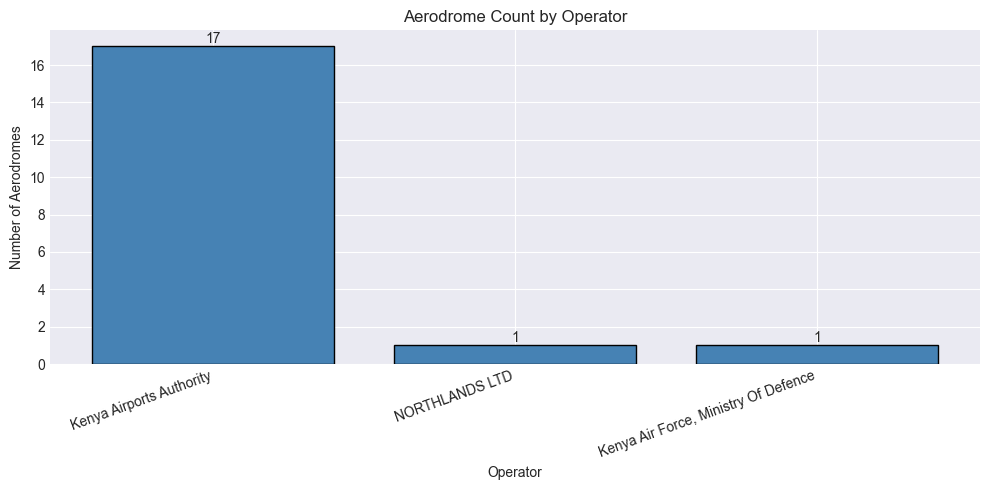

```python
operator_counts = aerodromes['operator'].value_counts()

plt.figure(figsize=(10, 5))
bars = plt.bar(operator_counts.index, operator_counts.values, color='steelblue', edgecolor='black')
plt.xlabel('Operator')
plt.ylabel('Number of Aerodromes')
plt.title('Aerodrome Count by Operator')
plt.xticks(rotation=20, ha='right')

for bar in bars:
    height = bar.get_height()
    plt.text(bar.get_x() + bar.get_width()/2., height,
             f'{int(height)}', ha='center', va='bottom')

plt.tight_layout()
plt.show()
```

## Part 4: Advanced Analysis — Aviation Safety & Planning

Now we're getting into real GIS engineering work. These analyses are similar to what professionals do for aviation authorities.

### 4.1 IDENTIFYING ISOLATED AERODROMES

```python
from scipy.spatial import KDTree

coords = aerodromes[['latitude', 'longitude']].dropna().values
icaos  = aerodromes.loc[aerodromes[['latitude', 'longitude']].dropna().index, 'icao'].values

tree = KDTree(coords)
distances, _ = tree.query(coords, k=2)  # k=2: self + nearest neighbor
nearest_distances = distances[:, 1] * 111  # rough degrees-to-km

isolation_analysis = pd.DataFrame({
    'icao': icaos,
    'nearest_distance_km': nearest_distances
}).sort_values('nearest_distance_km', ascending=False)

print("TOP 10 MOST ISOLATED AERODROMES:")
isolation_analysis.head(10)
```

```
TOP 10 MOST ISOLATED AERODROMES:
```

|  | icao | nearest_distance_km |
| --- | --- | --- |
| 8 | HKLK | 365.104241 |
| 18 | HKWJ | 317.794842 |
| 9 | HKLU | 140.519824 |
| 11 | HKML | 105.105025 |
| 10 | HKMJ | 76.526559 |
| 15 | HKOK | 76.526559 |
| 1 | HKEM | 75.763728 |
| 13 | HKNL | 75.508269 |
| 3 | HKIS | 75.508269 |
| 7 | HKKT | 70.200020 |

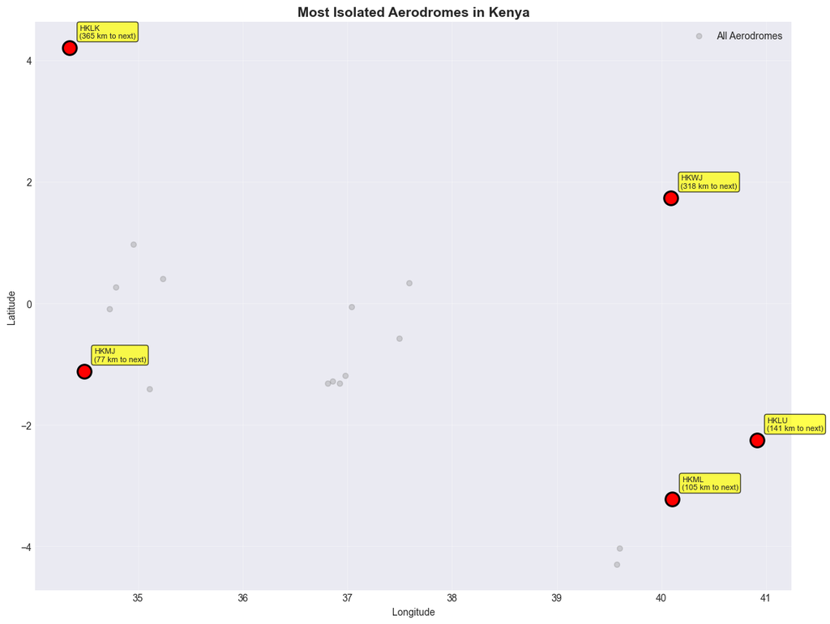

```python
# Visualize isolated aerodromes
plt.figure(figsize=(12, 9))

plt.scatter(aerodromes['longitude'], aerodromes['latitude'],
            alpha=0.3, s=30, c='gray', label='All Aerodromes')

top_isolated = isolation_analysis.head(5)
for _, row in top_isolated.iterrows():
    airport = aerodromes[aerodromes['icao'] == row['icao']].iloc[0]
    plt.scatter(airport['longitude'], airport['latitude'],
                s=200, c='red', edgecolors='black', linewidth=2, zorder=5)
    plt.annotate(f"{airport['icao']}\n({row['nearest_distance_km']:.0f} km to next)",
                 (airport['longitude'], airport['latitude']),
                 xytext=(10, 10), textcoords='offset points', fontsize=8,
                 bbox=dict(boxstyle='round,pad=0.3', facecolor='yellow', alpha=0.7))

plt.xlabel('Longitude')
plt.ylabel('Latitude')
plt.title('Most Isolated Aerodromes in Kenya', fontsize=14, fontweight='bold')
plt.legend()
plt.grid(True, alpha=0.3)
plt.tight_layout()
plt.show()
```

### 4.2 ELEVATION ZONES ANALYSIS

```
Aerodromes by elevation zone:
elevation_zone
Mountain (5000-7000 ft)    5
Highland (3000-5000 ft)    5
Lowland (<1000 ft)         5
Midland (1000-3000 ft)     4
Name: count, dtype: int64
```

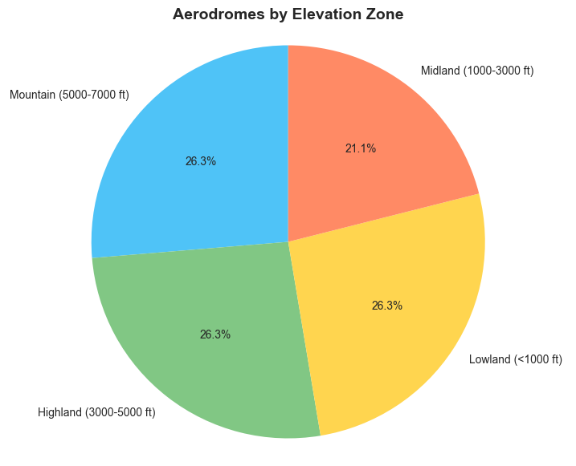

```python
def elevation_zone(elevation):
    if pd.isna(elevation):       return 'Unknown'
    elif elevation < 1000:        return 'Lowland (<1000 ft)'
    elif elevation < 3000:        return 'Midland (1000-3000 ft)'
    elif elevation < 5000:        return 'Highland (3000-5000 ft)'
    elif elevation < 7000:        return 'Mountain (5000-7000 ft)'
    else:                         return 'Very High (>7000 ft)'

aerodromes['elevation_zone'] = aerodromes['elevation_ft'].apply(elevation_zone)

zone_counts = aerodromes['elevation_zone'].value_counts()
print("Aerodromes by elevation zone:")
print(zone_counts)

palette = ['#4FC3F7', '#81C784', '#FFD54F', '#FF8A65', '#E57373']
plt.figure(figsize=(9, 7))
plt.pie(zone_counts.values, labels=zone_counts.index, autopct='%1.1f%%',
        startangle=90, colors=palette)
plt.title('Aerodromes by Elevation Zone', fontsize=14, fontweight='bold')
plt.axis('equal')
plt.show()
```

### 4.3 AERODROME DENSITY HEATMAP

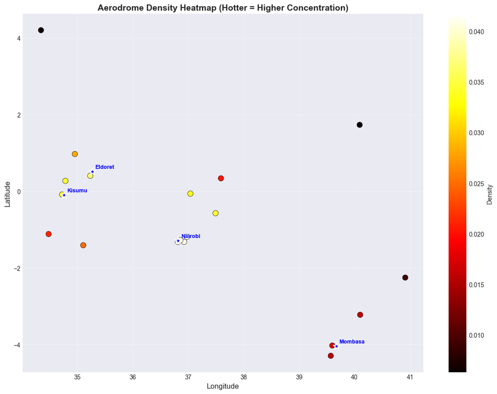

```python
from scipy.stats import gaussian_kde

x = aerodromes['longitude'].dropna()
y = aerodromes['latitude'].dropna()

xy = np.vstack([x, y])
z = gaussian_kde(xy)(xy)

idx = z.argsort()
x_s, y_s, z_s = x.iloc[idx], y.iloc[idx], z[idx]

plt.figure(figsize=(12, 9))
scatter = plt.scatter(x_s, y_s, c=z_s, s=80, cmap='hot', edgecolors='black', linewidth=0.5)
plt.colorbar(scatter, label='Density')

# Reference cities
cities = {'Nairobi': [-1.2864, 36.8172], 'Mombasa': [-4.0435, 39.6682],
          'Kisumu': [-0.1022, 34.7617], 'Eldoret': [0.5143, 35.2698]}
for city, coord in cities.items():
    plt.scatter(coord[1], coord[0], c='blue', s=120, marker='*',
                edgecolors='white', linewidth=1.5)
    plt.annotate(city, (coord[1], coord[0]), xytext=(5, 5),
                 textcoords='offset points', fontweight='bold', color='blue', fontsize=9)

plt.xlabel('Longitude', fontsize=12)
plt.ylabel('Latitude', fontsize=12)
plt.title('Aerodrome Density Heatmap (Hotter = Higher Concentration)',
          fontsize=14, fontweight='bold')
plt.grid(True, alpha=0.3)
plt.tight_layout()
plt.show()
```

### 4.4 ELEVATION PROFILE — South to North

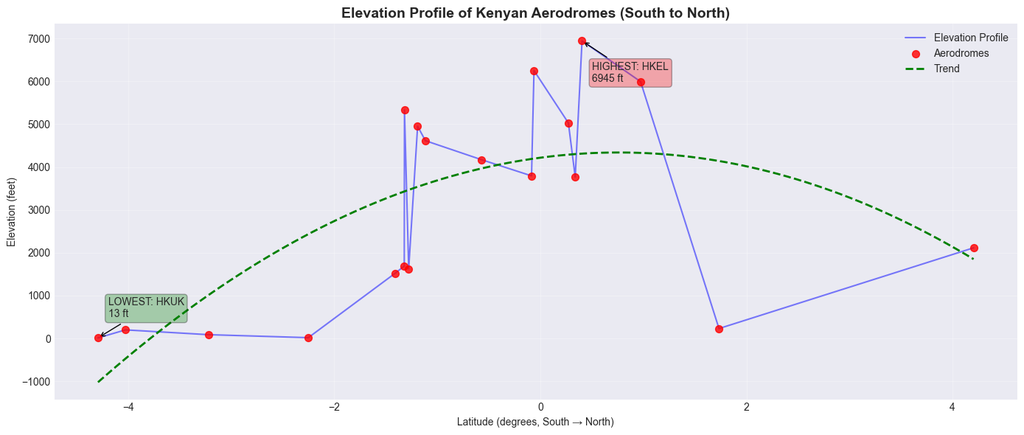

```python
sorted_airports = aerodromes.sort_values('latitude').dropna(subset=['elevation_ft'])

plt.figure(figsize=(14, 6))
plt.plot(sorted_airports['latitude'], sorted_airports['elevation_ft'],
         'b-', alpha=0.5, label='Elevation Profile')
plt.scatter(sorted_airports['latitude'], sorted_airports['elevation_ft'],
            c='red', s=50, alpha=0.8, label='Aerodromes', zorder=5)

# Trend line
z_fit = np.polyfit(sorted_airports['latitude'], sorted_airports['elevation_ft'], 2)
p_fit = np.poly1d(z_fit)
lat_range = np.linspace(sorted_airports['latitude'].min(), sorted_airports['latitude'].max(), 100)
plt.plot(lat_range, p_fit(lat_range), 'g--', linewidth=2, label='Trend')

# Annotate extremes
highest = sorted_airports.loc[sorted_airports['elevation_ft'].idxmax()]
lowest  = sorted_airports.loc[sorted_airports['elevation_ft'].idxmin()]

plt.annotate(f"HIGHEST: {highest['icao']}\n{highest['elevation_ft']:.0f} ft",
             (highest['latitude'], highest['elevation_ft']),
             xytext=(10, -40), textcoords='offset points',
             bbox=dict(boxstyle='round,pad=0.3', facecolor='red', alpha=0.3),
             arrowprops=dict(arrowstyle='->'))

plt.annotate(f"LOWEST: {lowest['icao']}\n{lowest['elevation_ft']:.0f} ft",
             (lowest['latitude'], lowest['elevation_ft']),
             xytext=(10, 20), textcoords='offset points',
             bbox=dict(boxstyle='round,pad=0.3', facecolor='green', alpha=0.3),
             arrowprops=dict(arrowstyle='->'))

plt.xlabel('Latitude (degrees, South → North)')
plt.ylabel('Elevation (feet)')
plt.title('Elevation Profile of Kenyan Aerodromes (South to North)', fontsize=14, fontweight='bold')
plt.legend()
plt.grid(True, alpha=0.3)
plt.tight_layout()
plt.show()
```

## Part 5: Advanced GIS Operations

Now we're doing real GIS engineering — spatial operations used in professional aviation work.

### 5.1 CREATING BUFFER ZONES

```python
# In aviation, buffer zones are used for obstacle limitation surfaces and noise monitoring.

def create_buffer_rectangle(center_lat, center_lon, size_km=10):
    """Return a rectangular bounding box around a centre point."""
    lat_offset = size_km / 111
    lon_offset = size_km / (111 * abs(math.cos(math.radians(center_lat))))
    return {
        'min_lat': center_lat - lat_offset,
        'max_lat': center_lat + lat_offset,
        'min_lon': center_lon - lon_offset,
        'max_lon': center_lon + lon_offset
    }

# 20 km buffer around JKIA
jkia = aerodromes[aerodromes['icao'] == 'HKJK'].iloc[0]
buffer_20km = create_buffer_rectangle(jkia['latitude'], jkia['longitude'], 20)

print(f"20 km buffer around {jkia['icao']}:")
print(f"  Latitude:  {buffer_20km['min_lat']:.4f} → {buffer_20km['max_lat']:.4f}")
print(f"  Longitude: {buffer_20km['min_lon']:.4f} → {buffer_20km['max_lon']:.4f}")

in_buffer = aerodromes[
    (aerodromes['latitude']  >= buffer_20km['min_lat']) &
    (aerodromes['latitude']  <= buffer_20km['max_lat']) &
    (aerodromes['longitude'] >= buffer_20km['min_lon']) &
    (aerodromes['longitude'] <= buffer_20km['max_lon']) &
    (aerodromes['icao'] != 'HKJK')
]

print(f"\nAerodromes within 20 km of JKIA: {len(in_buffer)}")
in_buffer[['icao', 'traffic', 'elevation_ft']]
```

```
20 km buffer around HKJK:
  Latitude:  -1.4994 → -1.1391
  Longitude: 36.7475 → 37.1080

Aerodromes within 20 km of JKIA: 3
```

|  | icao | traffic | elevation_ft |
| --- | --- | --- | --- |
| 2 | HKFP | IFR/VFR | 4953.0 |
| 14 | HKNW | IFR/VFR | 1690.0 |
| 16 | HKRE | IFR/VFR | 1626.0 |

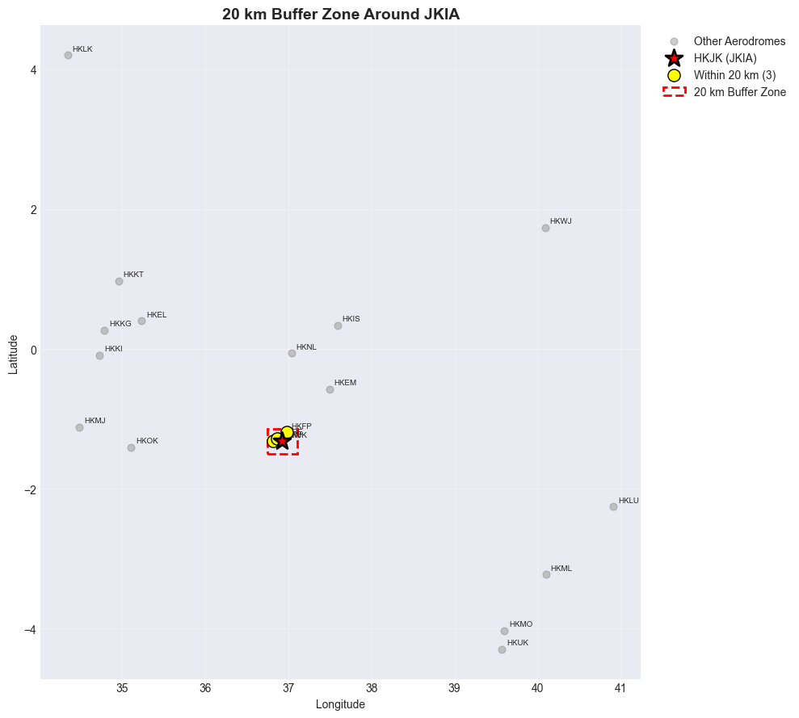

```python
# Visualize the JKIA buffer
from matplotlib.patches import Rectangle

plt.figure(figsize=(10, 9))

plt.scatter(aerodromes['longitude'], aerodromes['latitude'],
            alpha=0.4, s=40, c='gray', label='Other Aerodromes')

plt.scatter(jkia['longitude'], jkia['latitude'],
            s=250, c='red', marker='*', edgecolors='black', linewidth=2,
            label=f"{jkia['icao']} (JKIA)", zorder=5)

if len(in_buffer) > 0:
    plt.scatter(in_buffer['longitude'], in_buffer['latitude'],
                s=120, c='yellow', edgecolors='black', linewidth=1,
                label=f'Within 20 km ({len(in_buffer)})', zorder=4)

rect = Rectangle(
    (buffer_20km['min_lon'], buffer_20km['min_lat']),
    buffer_20km['max_lon'] - buffer_20km['min_lon'],
    buffer_20km['max_lat'] - buffer_20km['min_lat'],
    linewidth=2, edgecolor='red', facecolor='none', linestyle='--',
    label='20 km Buffer Zone'
)
plt.gca().add_patch(rect)

# Label all aerodromes
for _, row in aerodromes.iterrows():
    plt.annotate(row['icao'], (row['longitude'], row['latitude']),
                 xytext=(4, 4), textcoords='offset points', fontsize=7)

plt.xlabel('Longitude')
plt.ylabel('Latitude')
plt.title(f'20 km Buffer Zone Around JKIA', fontsize=14, fontweight='bold')
plt.legend(bbox_to_anchor=(1.02, 1), loc='upper left')
plt.grid(True, alpha=0.3)
plt.tight_layout()
plt.show()
```

### 5.2 HAVERSINE DISTANCE — Nearest Other Aerodrome to JKIA

```python
def haversine_distance(lat1, lon1, lat2, lon2):
    """Great-circle distance in km between two lat/lon points."""
    R = 6371
    lat1, lon1, lat2, lon2 = map(math.radians, [lat1, lon1, lat2, lon2])
    dlat, dlon = lat2 - lat1, lon2 - lon1
    a = math.sin(dlat/2)**2 + math.cos(lat1) * math.cos(lat2) * math.sin(dlon/2)**2
    return R * 2 * math.asin(math.sqrt(a))

jkia_lat, jkia_lon = jkia['latitude'], jkia['longitude']

distances = []
for _, row in aerodromes.iterrows():
    if row['icao'] != 'HKJK' and pd.notna(row['latitude']):
        dist = haversine_distance(jkia_lat, jkia_lon, row['latitude'], row['longitude'])
        distances.append({'icao': row['icao'], 'distance_km': round(dist, 1), 'traffic': row['traffic']})

distance_df = pd.DataFrame(distances).sort_values('distance_km')
print("Nearest aerodromes to JKIA:")
distance_df
```

```
Nearest aerodromes to JKIA:
```

|  | icao | distance_km | traffic |
| --- | --- | --- | --- |
| 15 | HKRE | 8.8 | IFR/VFR |
| 13 | HKNW | 12.5 | IFR/VFR |
| 2 | HKFP | 15.3 | IFR/VFR |
| 1 | HKEM | 104.3 | IFR/VFR |
| 12 | HKNL | 140.3 | IFR/VFR |
| 3 | HKIS | 198.5 | IFR/VFR |
| 14 | HKOK | 202.3 | IFR/VFR |
| 0 | HKEL | 268.5 | IFR/VFR |
| 9 | HKMJ | 272.4 | VFR |
| 5 | HKKI | 280.3 | IFR/VFR |
| 4 | HKKG | 296.4 | VFR |
| 6 | HKKT | 335.9 | VFR |
| 10 | HKML | 411.2 | IFR/VFR |
| 11 | HKMO | 422.6 | IFR/VFR |
| 16 | HKUK | 442.2 | IFR/VFR |
| 8 | HKLU | 454.9 | IFR/VFR |
| 17 | HKWJ | 488.8 | IFR/VFR |
| 7 | HKLK | 677.8 | IFR/VFR |

### 5.3 CLUSTER ANALYSIS WITH DBSCAN

```python
from sklearn.cluster import DBSCAN

coords_cluster = aerodromes[['latitude', 'longitude']].dropna().values
clustering = DBSCAN(eps=0.5, min_samples=2).fit(coords_cluster)

aerodromes_clustered = aerodromes.loc[aerodromes[['latitude', 'longitude']].dropna().index].copy()
aerodromes_clustered['cluster'] = clustering.labels_

n_clusters = len(set(clustering.labels_)) - (1 if -1 in clustering.labels_ else 0)
n_noise    = list(clustering.labels_).count(-1)

print(f"Found {n_clusters} cluster(s) of aerodromes")
print(f"{n_noise} aerodrome(s) are isolated (not in any cluster)")

print("\nAerodromes by cluster:")
for cluster_id in sorted(set(clustering.labels_)):
    label = 'Isolated' if cluster_id == -1 else f'Cluster {cluster_id}'
    members = aerodromes_clustered[aerodromes_clustered['cluster'] == cluster_id]
    print(f"\n{label} ({len(members)} aerodromes):")
    for _, row in members.iterrows():
        print(f"  - {row['icao']}")
```

```
Found 3 cluster(s) of aerodromes
10 aerodrome(s) are isolated (not in any cluster)

Aerodromes by cluster:

Isolated (10 aerodromes):
  - HKEM
  - HKIS
  - HKKT
  - HKLK
  - HKLU
  - HKMJ
  - HKML
  - HKNL
  - HKOK
  - HKWJ

Cluster 0 (3 aerodromes):
  - HKEL
  - HKKG
  - HKKI

Cluster 1 (4 aerodromes):
  - HKFP
  - HKJK
  - HKNW
  - HKRE

Cluster 2 (2 aerodromes):
  - HKMO
  - HKUK
```

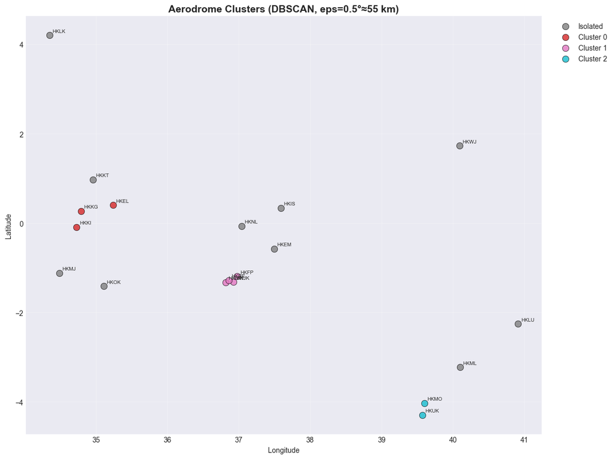

```python
# Visualize clusters
plt.figure(figsize=(12, 9))

unique_clusters = sorted(set(clustering.labels_))
colors_map = plt.cm.tab10(np.linspace(0, 1, len(unique_clusters)))

for cluster_id, color in zip(unique_clusters, colors_map):
    subset = aerodromes_clustered[aerodromes_clustered['cluster'] == cluster_id]
    label  = 'Isolated' if cluster_id == -1 else f'Cluster {cluster_id}'
    c_col  = 'gray' if cluster_id == -1 else color
    plt.scatter(subset['longitude'], subset['latitude'],
                c=[c_col], s=80, label=label,
                edgecolors='black', linewidth=0.6, alpha=0.8)

for _, row in aerodromes_clustered.iterrows():
    plt.annotate(row['icao'], (row['longitude'], row['latitude']),
                 xytext=(4, 4), textcoords='offset points', fontsize=7)

plt.xlabel('Longitude')
plt.ylabel('Latitude')
plt.title('Aerodrome Clusters (DBSCAN, eps=0.5°≈55 km)', fontsize=14, fontweight='bold')
plt.legend(bbox_to_anchor=(1.02, 1), loc='upper left')
plt.grid(True, alpha=0.3)
plt.tight_layout()
plt.show()
```

## 🎯 Summary

In this session we worked through a complete Python + GIS workflow for Kenya's AIP aerodromes dataset:

| Part | Topics Covered |
| --- | --- |
| **1 – Python Basics** | Variables, data types, lists, dicts, loops, functions |
| **2 – Data Loading** | Parsing GeoJSON with Python `json`, building a Pandas DataFrame |
| **3 – Visualization** | Scatter plots, colour coding, histograms, box plots, bar charts |
| **4 – Analysis** | Isolation analysis (KD-Tree), elevation zones, density heatmap, profile |
| **5 – GIS Ops** | Buffer zones, Haversine distance, DBSCAN cluster analysis |

> **Next Steps**: Try loading the GeoJSON data via `geopandas` for full GIS projection support and interactive `folium` maps!